# Regression Discontinuity | Codethrough

PAF 512 - Advanced Regression

# What Will We Cover?

#### 1. Understanding the Problem: Selection at a Cutoff

- When programs use cutoffs, comparison groups are fundamentally different
- Sharp vs. Fuzzy RDD (and how to tell which you have)

#### 2. The Policy Problem

- Research question: Does winning a close election help you win the next one?
- The U.S. Senate election data

#### 3. The Naive Comparison

- Compare winners vs. losers directly
- Why this comparison is misleading

#### 4. The Regression Discontinuity Solution

- The key insight: near the cutoff, treatment is basically random
- The model formula and what each coefficient means
- Linear vs. polynomial approaches

#### 5. The Basic Approach: Using `lm()`

- Run RDD with familiar tools
- Interpret the coefficients
- Visualize the discontinuity
- Limitations of this approach

#### 6. The Professional Approach: Using `rdrobust()`

- Why `rdrobust()` is the industry standard
- Understanding bandwidth selection
- Reading the output (what all those numbers mean)
- Testing sensitivity to bandwidth choices
- Visualizing with `rdplot()`

#### 7. Understanding the Counterfactual

- What would have happened to winners if they had lost?
- The Local Average Treatment Effect (LATE)

#### 8. Checking Assumptions

- Is our design actually sharp?
- Could people have manipulated their scores?

#### 9. The Final Verdict

- Summary of findings
- The RDD workflow for your lab

# Understanding the Problem

## When Cutoffs Create Trouble

Many programs and policies use cutoffs to determine who gets in:

- Students scoring below 60 on a test must attend summer school
- Families earning below a threshold qualify for housing assistance
- Candidates receiving more than 50% of votes win elections

The problem? People on opposite sides of these cutoffs are usually very different from each other. A student who scored 30 on a math test is not comparable to a student who scored 90. If we simply compare the outcomes of these two groups, we’re comparing apples to oranges.

This is the same selection problem we’ve encountered before - the groups differ in ways that affect both their treatment status AND their outcomes.

## The RDD Insight

Here’s the key insight that makes Regression Discontinuity work: **people right at the cutoff are nearly identical.**

Think about it. What’s really the difference between a student who scored 59 and one who scored 61? Not much - maybe the 59 had a bad day, or got unlucky on one question. These students have essentially the same underlying ability, but one gets the treatment (summer school) and one doesn’t.

Near the cutoff, whether you end up just above or just below is basically random. This is called **local randomization** - and it’s what allows us to estimate causal effects.

## Sharp vs. Fuzzy RDD

Before we dive in, there’s an important distinction to understand:

**Sharp RDD:** The cutoff perfectly determines treatment. Everyone below gets treated, everyone above doesn’t (or vice versa). No exceptions.

- Example: You win an election if and only if you get more than 50% of the vote
- Example: Students below 60 MUST attend summer school, no opt-outs allowed

**Fuzzy RDD:** The cutoff affects the probability of treatment, but doesn’t perfectly determine it. Some people above the cutoff still get treated, or some below don’t.

- Example: Students below 60 are recommended for tutoring, but attendance is optional
- Example: Income below threshold makes you eligible for a program, but you have to apply

Fuzzy RDD is more complicated and requires instrumental variable techniques. For this course, we’ll focus on **sharp RDD**, which is conceptually cleaner.

**Instructor’s Note:**

How do you know if your design is sharp or fuzzy? Plot it! If treatment status jumps from 0 to 1 exactly at the cutoff (a perfect step function), it’s sharp. If there’s a jump but it’s not from 0 to 1 (say, from 20% to 80%), it’s fuzzy. We’ll show you how to check this later.

If you encounter a fuzzy design in your own research, the `rdrobust` package can handle it, but the interpretation becomes more complex. For more on fuzzy RDD, see Angrist and Pischke’s “Mostly Harmless Econometrics.”

# The Policy Problem

## Research Question

**Does winning a close election give you an advantage in the next election?**

This is a classic question in political science. Incumbents (people currently holding office) tend to win re-election at high rates. But is this because being an incumbent actually helps you? Or is it just that good candidates both win elections AND keep winning?

Think about it: candidates who win elections might be more charismatic, better funded, or more aligned with their constituents. These same traits would help them win future elections regardless of whether they’re incumbents.

## Why Elections Are Perfect for RDD

Elections have a beautiful property: there’s a sharp cutoff. If you get the most votes, you win. If you get less, you lose. There’s no gray area.

And here’s the key: in a very close election, whether you end up at 50.1% or 49.9% is essentially random. Maybe a few voters got stuck in traffic, or the weather was different in one part of the district. The candidates themselves are nearly identical in quality - that’s why the election was so close!

By comparing candidates who barely won to candidates who barely lost, we can isolate the causal effect of incumbency itself.

## The Data

We’ll use the **U.S. Senate election dataset** which contains Senate election results from 1914 - 2010 and is built into the `rdrobust` package.

### Key Variables

| Variable | Description |
| --- | --- |
| `margin` | Calculated by subtracting the percentage of the Republican votes from the percentage of Democratic votes (% Democrat - % Republican) in election $t$. Positive means Democrats won, negative means they … |
| `vote` | Democratic vote share in the NEXT election ($t+1$) for that same Senate seat. This is our **outcome variable**. |

The cutoff is at `margin = 0`. If `margin > 0`, Democrats won and become incumbents. If `margin < 0`, Democrats lost.

**Instructor’s Note:**

In your lab you will need to center the running variable yourself, while in this dataset the running variable `margin` is already centered. We center the running variable to make interpretation meaningful. See the note in the lecture within section 2.2 under $B_2$ explanation.

## Setup and Data Loading

```r
# Install packages if needed
# install.packages("rdrobust")
# install.packages("stargazer")

library(rdrobust)
library(stargazer)

# Load the Senate election data (built into rdrobust)
data("rdrobust_RDsenate")

# Let's give it a shorter name
senate <- rdrobust_RDsenate

# Check what we're working with
head(senate)
```

```
##        margin     vote
## 1  -7.6885610 36.09757
## 2  -3.9237082 45.46875
## 3  -6.8686604 45.59821
## 4 -27.6680565 48.47606
## 5  -8.2569685 51.74687
## 6   0.7324815 39.80264
```

It is crucial to understand exactly what the data represents. Our running variable, `margin` represents the difference in percentage of the vote between the Democrat candidate and the Republican. A negative value represents the Democratic Candidate lost and by how many percentage points. Look at our first row, the value $-7.69$ which means the Democratic candidate lost by ~$7.7\%$. The `vote` variable represents the proportion of total votes they received at the next election, 6 years later. The farther away from $0$, the farther from the cutoff.

```r
# Total number of rows in our data
nrow(senate)
```

```
## [1] 1390
```

```r
# Summary statistics
summary(senate)
```

```
##      margin              vote
##  Min.   :-100.000   Min.   :  0.00
##  1st Qu.: -12.206   1st Qu.: 42.67
##  Median :   2.166   Median : 50.55
##  Mean   :   7.171   Mean   : 52.67
##  3rd Qu.:  22.766   3rd Qu.: 61.35
##  Max.   : 100.000   Max.   :100.00
##                     NA's   :93
```

Let’s visualize the data to get a feel for what we’re working with:

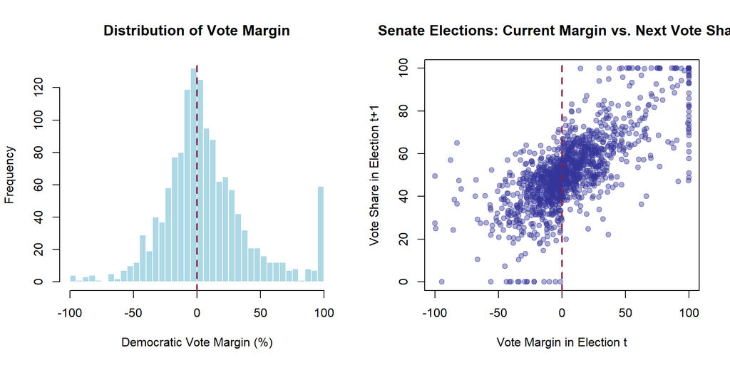

```r
# Set up a two-panel plot
par(mfrow = c(1, 2))

# Left panel: Distribution of margin (running variable)
hist(senate$margin,
     breaks = 40,
     main = "Distribution of Vote Margin",
     xlab = "Democratic Vote Margin (%)",
     col = "lightblue",
     border = "white")
abline(v = 0, col = "#8C1D40", lwd = 2, lty = 2)

# Right panel: Relationship between margin and next election vote share
plot(senate$margin, senate$vote,
     pch = 19,
     col = rgb(0.2, 0.2, 0.6, 0.4),
     xlab = "Vote Margin in Election t",
     ylab = "Vote Share in Election t+1",
     main = "Senate Elections: Current Margin vs. Next Vote Share")
abline(v = 0, col = "#8C1D40", lwd = 2, lty = 2)
```

Already we can see something interesting in the right panel - there appears to be a “jump” right at the cutoff. Candidates who barely won seem to do better in the next election than candidates who barely lost. That’s the discontinuity we’re trying to measure!

# The Naive Comparison

Before we use RDD, let’s see what happens when we just compare winners to losers directly. This will show us why we need a more sophisticated approach.

## Create Treatment Variable

First, we need a variable indicating who won (treatment) vs. who lost (control):

```r
# Create treatment variable: 1 if Democrats won, 0 if they lost
senate$treat <- ifelse(senate$margin > 0, 1, 0)

# Check the split
table(senate$treat)
```

```
##
##   0   1
## 640 750
```

## Compare Group Means

Now let’s compare the average next-election vote share for winners vs. losers:

```r
# Calculate means for each group
mean_winners <- mean(senate$vote[senate$treat == 1], na.rm = TRUE)
mean_losers <- mean(senate$vote[senate$treat == 0], na.rm = TRUE)

cat("Average next-election vote share:\n",
    "  Winners (incumbents):", round(mean_winners, 2), "%\n",
    "  Losers:", round(mean_losers, 2), "%\n",
    "  Difference:", round(mean_winners - mean_losers, 2), "percentage points\n")
```

```
## Average next-election vote share:
##    Winners (incumbents): 62.62 %
##    Losers: 40.92 %
##    Difference: 21.7 percentage points
```

That’s a big difference! Winners get about $21.7$ percentage points more in the next election.

## T-Test

Let’s confirm this difference is statistically significant:

```r
# T-test comparing winners to losers
t_result <- t.test(vote ~ treat, data = senate)
print(t_result)
```

```
##
##  Welch Two Sample t-test
##
## data:  vote by treat
## t = -27.409, df = 1275.5, p-value < 2.2e-16
## alternative hypothesis: true difference in means between group 0 and group 1 is not equal to 0
## 95 percent confidence interval:
##  -23.25446 -20.14790
## sample estimates:
## mean in group 0 mean in group 1
##        40.92053        62.62170
```

The results of our t-test suggest we can be 95% confident that the mean difference between the two groups is between ~20 and ~23 percentage points. However, this estimate is **unreliable** for identifying a causal effect.

## Why This Is Wrong

The problem is that we’re comparing ALL winners to ALL losers. But candidates who won by 20 points are very different from candidates who lost by 20 points. The winners were probably better candidates to begin with - more popular, better funded, more skilled campaigners.

Let’s see this visually:

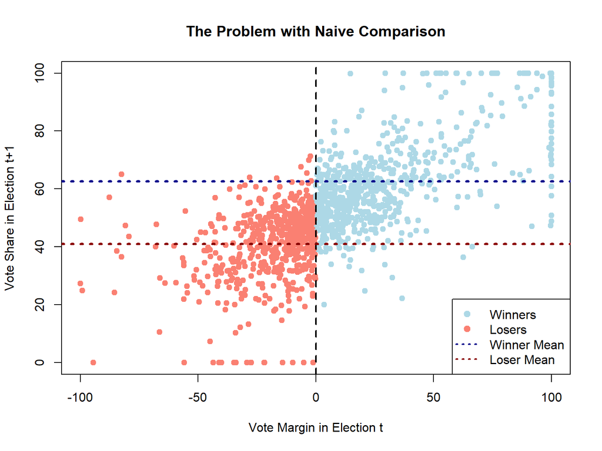

```r
# Color points by treatment status
colors <- ifelse(senate$treat == 1,
                 "lightblue",   # Blue for winners
                 "salmon")   # Red for losers

plot(senate$margin, senate$vote,
     pch = 19, col = colors,
     xlab = "Vote Margin in Election t",
     ylab = "Vote Share in Election t+1",
     main = "The Problem with Naive Comparison")
abline(v = 0, col = "black", lwd = 2, lty = 2)

# Add group means as horizontal lines
abline(h = mean_winners, col = "darkblue", lwd = 3, lty = 3)
abline(h = mean_losers, col = "darkred", lwd = 3, lty = 3)

# Legend
legend("bottomright",
       legend = c("Winners", "Losers", "Winner Mean", "Loser Mean"),
       col = c("lightblue", "salmon", "darkblue", "darkred"),
       pch = c(19, 19, NA, NA),
       lty = c(NA, NA, 3, 3),
       lwd = 2)
```

See the problem? The blue points (winners) are clustered on the right side of the graph - they had higher margins to begin with. The red points (losers) are on the left. We’re not comparing similar candidates at all.

# The Regression Discontinuity Solution

## The Key Insight

The RDD focuses on measurement to only compare candidates **right at the cutoff**.

A candidate who won with $1\%$ and a candidate who lost with $1\%$ are essentially identical in terms of candidate quality, campaign resources, and voter appeal. The only meaningful difference is that one is now an incumbent and one isn’t.

By focusing on this narrow window around the cutoff, we’re essentially running a natural experiment.

## The Model

The basic RDD model looks like this:

$$Y = \beta_0 + \beta_1 \cdot Treatment +
\beta_2 \cdot Running\_Variable + \epsilon$$

For our Senate data:

$$Vote_{t+1} = \beta_0 + \beta_1 \cdot
Win_t + \beta_2 \cdot Margin_t + \epsilon$$

### What Each Coefficient Means

| Coefficient | Interpretation |
| --- | --- |
| $\beta_0$ | Predicted outcome for a **loser** right at the cutoff (margin = 0) |
| $\beta_1$ | The **treatment effect** - the “jump” at the cutoff. This is what we care about! |
| $\beta_2$ | The relationship between margin and next-election vote share (the slope) |

# The Naive (biased) RDD Approach:

**Instructor’s Note: `lm()` is the wrong approach**

In your lecture materials you saw the use of `lm()` as a method of running a Regresssion Discontinuity Design. This helps us understand what’s happening under the hood; however, **it is critical to note that using using a model with parallel trends produces a biased estimate. What you learned in your lecture is strictly for pedagogical purposes and is not the method you should use for actual inference testing.**

## Run the Model

```r
# RDD model with lm()
# Recall, margin is already centered at 0
rdd_lm <- lm(vote ~ treat + margin, data = senate)

stargazer(rdd_lm,
          type = "text",
          #type = "html",
          title = "RDD Model Using lm()",
          dep.var.labels = "Vote Share in Next Election",
          covariate.labels = c("Won Election (Treatment)",
                               "Vote Margin"),
          omit.stat = c("f", "ser"),
          digits = 3)
```

# RDD Model Using lm()

[output not shown]

## Interpret the Coefficients

Let’s break down what each coefficient tells us:

`Treatment`:

- $b_1$ coefficient represents level-change at the cutoff, this is the impact of incumbency at the cutoff (in a close race). Being the incumbent is estimated to generate an additional $4.785\%$ of the share of votes, but only in a close race (around the cutoff).

`Vote Margin`:

- $b_2$ is the slope, for every additional percentage point of `margin` earned during the first election cycle, we can estimate an additional $0.348\%$ points in the next election.

`Intercept`:

- $b_0$, our constant, represents the estimated proportion of the vote share for the Democratic candidate that lost the election at the cutoff (`margin` = 0). In our case, the average proportion of vote share is $47.33\%$.

**The key finding:** Winning a close election causes about a $4.8$ percentage point increase in the next election’s vote share. That’s the incumbency advantage - and it’s quite a bit smaller than the naive $21$-point estimate we got earlier!

## Visualize the Discontinuity

Let’s create a plot that shows the RDD visually:

``` r # Extract coefficients from our lm() model b0 <- coef(rdd_lm)[1] # Intercept b1 <- coef(rdd_lm)[2] # Treatment effect b2 <- coef(rdd_lm)[3] # Slope (margin coefficient)

# Set up colors col_control <- “salmon” # Red for losers col_treat <- “lightblue” # Blue for winners

# Create the scatter plot plot(senate$margin, senate$vote, pch = 19, col = ifelse(senate$treat == 1, col_treat, col_control), xlab = “Vote Margin in Election t (%)”, ylab = “Vote Share in Election t+1 (%)”, main = “Regression Discontinuity: Incumbency Advantage in Senate Elections”)

# Add vertical line at cutoff abline(v = 0, col = “black”, lwd = 2, lty = 2)

# Add fitted lines for each group # For losers (margin < 0): Y = b0 + b2*margin # For winners (margin > 0): Y = b0 + b1 + b2*margin

margin_seq_control <- seq(min(senate$margin, na.rm = TRUE), 0, length.out = 100) margin_seq_treat <- seq(0, max(senate$margin, na.rm = TRUE), length.out = 100)

fitted_control <- b0 + b2 * margin_seq_control fitted_treat <- b0 + b1 + b2 * margin_seq_treat

lines(margin_seq_control, fitted_control, col = “darkred”, lwd = 3) lines(margin_seq_treat, fitted_treat, col = “darkblue”, lwd = 3)

# Add legend legend(“bottomright”, legend = c(“Losers”, “Winners”, “Fitted (Losers)”, “Fitted (Winners)”, “Cutoff”), col = c(col_control, col_treat, “darkred”, “darkblue”, “black”), pch = c(19, 19, NA, NA, NA), lty = c(NA, NA, 1, 1, 2), lwd = c(NA, NA, 3, 3, 2), bg = “white”)

# Add annotation showing the “jump” arrows(2, b0, 2, b0 + b1, col = “black”, lwd = 2, code = 3, length = 0.1) text(22, 50, paste(“Treatment Effect=”, round(b1, 1), “points”), col = “black”, font = 2) ```

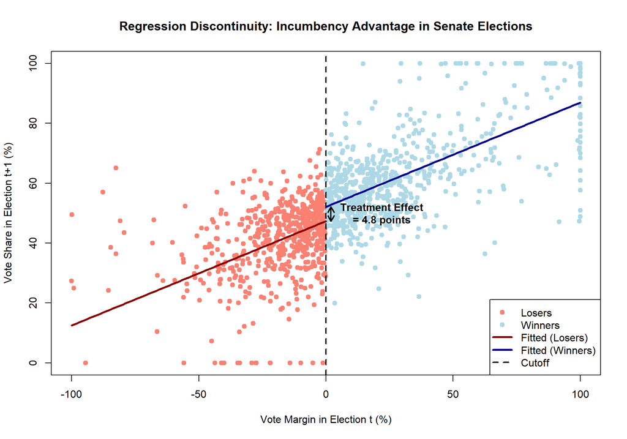

The “jump” between the two lines at the cutoff is our treatment effect. You can see it’s substantial - winning a close election really does boost your performance in the next election.

## The Interaction Model `lm()`

There is a subtle but important assumption we made in the previous model: we assumed the slope was the same for winners and losers.

Look closely at the formula we used: `vote ~ treat + margin`. This forces R to fit parallel lines. It assumes that the relationship between the margin and future votes is exactly the same for winners and losers, just shifted up or down.

But what if winning changes the relationship itself? What if incumbents gain votes at a different rate than challengers? To allow for this, we need to include an **interaction term**.

We change our formula to:

$$Vote_{t+1} = \beta_0 +
\beta_1 \cdot Win_t + \beta_2 \cdot Margin_t + \beta_3 \cdot (Win_t
\times Margin_t) + \epsilon$$

This allows the two groups to have different slopes:

- **Losers’ Slope:** $\beta_2$ - **Winners’ Slope:** $\beta_2 + \beta_3$

### Run the Interaction Model

We can simply multiply the variables (`treat * margin`) to automatically include the main effects and the interaction.

``` r # The long hand approach for an interaction term rdd_interaction <- lm(vote ~ treat + margin + treat:margin, data = senate)

# Technically, you can also use the shorthand approach for the same output rdd_interaction_shorthand <- lm(vote ~ treat * margin, data = senate)

stargazer(rdd_lm,rdd_interaction, rdd_interaction_shorthand, type = “text”, #type = “html”, title = “RDD Model with Interaction”, column.labels = c(“Basic”, “Interaction Long”, “Interaction Short”), dep.var.labels = “Vote Share in Next Election”, covariate.labels = c(“Won Election (Treatment)”, “Vote Margin”, “Interaction (Treat x Margin)”), omit.stat = c(“f”, “ser”), digits = 3) ```

`## ## RDD Model with Interaction ## ========================================================================= ## Dependent variable: ## -------------------------------------------- ## Vote Share in Next Election ## Basic Interaction Long Interaction Short ## (1) (2) (3) ## ------------------------------------------------------------------------- ## Won Election (Treatment) 4.785*** 6.044*** 6.044*** ## (0.923) (0.942) (0.942) ## ## Vote Margin 0.348*** 0.216*** 0.216*** ## (0.013) (0.028) (0.028) ## ## Interaction (Treat x Margin) 0.170*** 0.170*** ## (0.032) (0.032) ## ## Constant 47.331*** 44.904*** 44.904*** ## (0.542) (0.699) (0.699) ## ## ------------------------------------------------------------------------- ## Observations 1,297 1,297 1,297 ## R2 0.578 0.587 0.587 ## Adjusted R2 0.577 0.586 0.586 ## ========================================================================= ## Note: *p<0.1; **p<0.05; ***p<0.01`

### Interpret the Coefficients

Let’s look at how our results change:

`Treatment`:

- $b_1$ coefficient represents the level-change at the cutoff, this is the impact of incumbency. Being the incumbent is estimated to generate an additional $6.044\%$ of the share of votes. Notice the increase in treatment coefficient compared to the original model. Removing the restriction to have parrallel lines on each side of the cutoff allowed for room to more accurately assess the treatment effect, thus the increase in effect size.

`Vote Margin`:

- $b_2$ now represents the slope of those who lost. For every additional percentage point of `margin` earned during the first election cycle, we can estimate an additional $0.216\%$ points in the next election. This is decreased from our original model because our interaction term provides distinct slopes rather than a single aggregate slope. Thus revealing the slope of those who lost no longer driven up by the weight of those who won.

`Intercept`:

- $b_0$, our constant also changed. It continues to represent the estimated proportion of the vote share for the Democratic candidate that lost the election at the cutoff (`margin` = 0) but it dropped when allowing for differing slopes. A more accurate average proportion of vote share for the loser is $44.90\%$.

### Visualize the Interaction

Let’s plot this to see the difference. We will now calculate separate fitted lines that are allowed to have different angles.

``` r # Extract coefficients from the interaction model b0 <- coef(rdd_interaction)[1] # Intercept b1 <- coef(rdd_interaction)[2] # Treatment (Jump) b2 <- coef(rdd_interaction)[3] # Margin (Loser Slope) b3 <- coef(rdd_interaction)[4] # Interaction (Difference in Slopes)

# Create the scatter plot plot(senate$margin, senate$vote, pch = 19, col = ifelse(senate$treat == 1, “lightblue”, “salmon”), xlab = “Vote Margin in Election t (%)”, ylab = “Vote Share in Election t+1 (%)”, main = “RDD with Interaction: Allowing Different Slopes”)

# Add vertical line at cutoff abline(v = 0, col = “black”, lwd = 2, lty = 2)

# Generate sequences for plotting margin_seq_control <- seq(min(senate$margin, na.rm = TRUE), 0, length.out = 100) margin_seq_treat <- seq(0, max(senate$margin, na.rm = TRUE), length.out = 100)

# Calculate fitted values # Losers: Y = b0 + b2*margin fitted_control <- b0 + b2* margin_seq_control

# Winners: Y = b0 + b1 + (b2 + b3)*margin # Note: We add b3 to the slope for the treatment group fitted_treat <- (b0 + b1) + (b2 + b3)* margin_seq_treat

# Draw the lines lines(margin_seq_control, fitted_control, col = “darkred”, lwd = 3) lines(margin_seq_treat, fitted_treat, col = “darkblue”, lwd = 3)

# Add Legend legend(“bottomright”, legend = c(“Losers”, “Winners”, “Losers Slope”, “Winners Slope”), col = c(“salmon”, “lightblue”, “darkred”, “darkblue”), pch = c(19, 19, NA, NA), lty = c(NA, NA, 1, 1), lwd = c(NA, NA, 3, 3)) ```

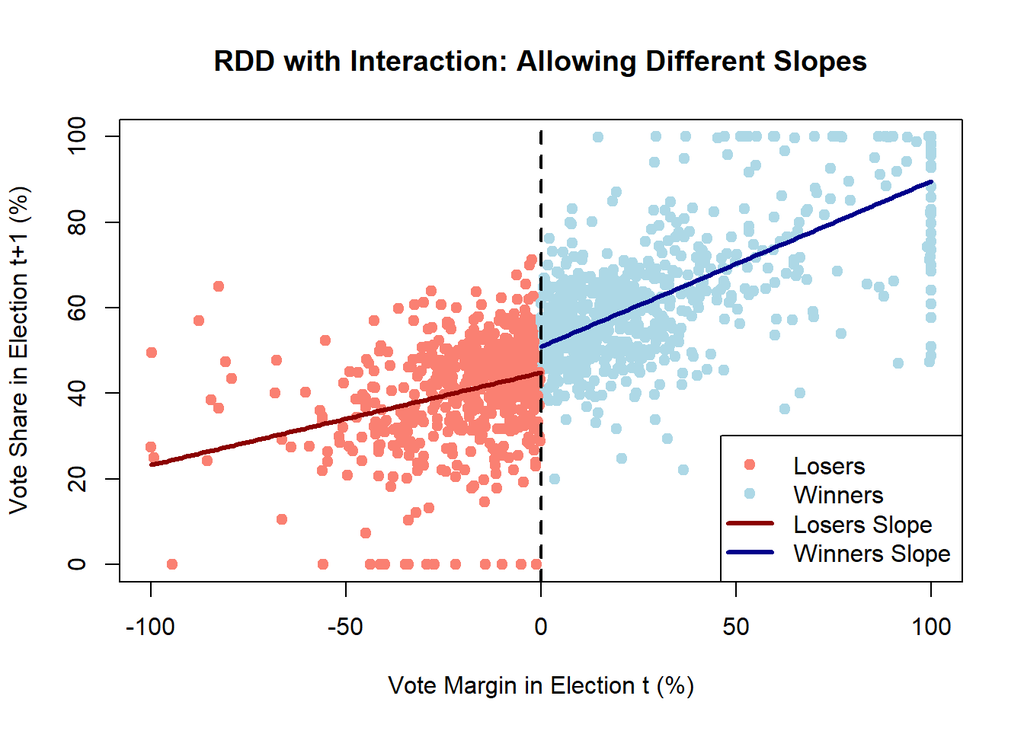

**Why this is better:** We can see a distinct increase in the slope of the incumbents compared to the slope of those whom lost.

## Limitations of the lm() Approach

The `lm()` approach is great for understanding, but it has some problems:

1. **Uses all the data:** We’re including candidates who won by 40 points alongside candidates who won by 1 point. But the RDD logic only really applies near the cutoff.

2. **Assumes linearity everywhere:** The relationship between margin and vote share might be curved, especially far from the cutoff.

3. **Standard errors may be wrong:** Technical issues with inference at boundaries mean our confidence intervals might not be reliable.

This is where `rdrobust()` comes in - it’s designed specifically for RDD and handles all these issues automatically.

# The Professional Approach

## Why rdrobust()?

The `rdrobust()` function is the industry standard for RDD analysis. It’s what you’ll see in published research, and it solves the problems with the basic `lm()` approach:

1. **Optimal bandwidth selection:** It automatically figures out how close to the cutoff to focus 2. **Bias correction:** It adjusts for the approximation error that comes from using local polynomials 3. **Proper standard errors:** It calculates confidence intervals that actually have the correct coverage 4. **Unique slopes:** Defaults to calculating different slopes on each side of the cutoff

Let’s see it in action.

## What Is Bandwidth?

The **bandwidth** is how far from the cutoff we look. A larger bandwidth contains more observations farther from the cutoff, while a narrow bandwidth contains less observation but closer to the cutoff.

- **Narrow bandwidth:** Only candidates very close to the cutoff (e.g., within 5 percentage points). Very comparable groups, but fewer observations means more noise.

- **Wide bandwidth:** Candidates further from the cutoff (e.g., within 20 points). More observations, but groups are less comparable.

There’s a tradeoff: zoom in too close and you don’t have enough data; zoom out too far and you’re comparing candidates who aren’t really similar.

`rdrobust()` calculates an optimal bandwidth that balances this tradeoff.

## Running rdrobust()

``` r # Run rdrobust # y = outcome variable # x = running variable # c = cutoff (default is 0) rd_model <- rdrobust(y = senate$vote, x = senate$margin, c = 0)

# Display results

#### IMPORTANT - stargazer & rdrobust() do not get along. You can simply use summary() summary(rd_model) ```

`## Sharp RD estimates using local polynomial regression. ## ## Number of Obs. 1297 ## BW type mserd ## Kernel Triangular ## VCE method NN ## ## Number of Obs. 595 702 ## Eff. Number of Obs. 360 323 ## Order est. (p) 1 1 ## Order bias (q) 2 2 ## BW est. (h) 17.754 17.754 ## BW bias (b) 28.028 28.028 ## rho (h/b) 0.633 0.633 ## Unique Obs. 595 665 ## ## ===================================================================== ## Point Robust Inference ## Estimate z P>|z| [ 95% C.I. ] ## --------------------------------------------------------------------- ## RD Effect 7.414 4.311 0.000 [4.094 , 10.919] ## =====================================================================`

That’s a lot of output! Let’s break it down.

## Reading the rdrobust() Output

The output gives us everything we need:

- `Number of Obs.` - The number of observations in our base dataset (minus NULLs).

- `BW type: mserd` - Method used to select bandwidth (Mean Squared Error, optimizes the balance between bias and variance).

- `Kernel: Triangular` - How observations are weighted (closer to cutoff = more weight).

- `VCE method: NN` - How standard errors are calculated (nearest neighbor)

- `Number of Obs.` - Total observations on each side

- `Eff. Number of Obs.` - Observations within the bandwidth (actually used)

- `Order est. ($p$)` - Polynomial order (1 = linear, 2 = quadratic)

- `Order Bias ($q$)` - Polynomial order used for bias correction. This is typically $p+1$ (so if you used a linear model $p=1$, this will be quadratic $q=2$). It helps estimate the error in the main line.

- `BW est. ($h$)` - The optimal bandwidth (above and below cutoff)

- `rho ($h/b$)` - The ratio of the main bandwidth to the bias-correction bandwidth. The bias bandwidth ($b$) is usually wider than the main bandwidth ($h$), so this number is typically less than 1.

- `Unique Obs.` - The number of distinct values of the running variable. If this number is very low compared to Number of Obs., it means many people have the exact same score (“mass points”), and you may need to cluster your standard errors.

**Bottom section - The results:** - `RD Effect` - **This is your treatment effect!**

- `$z$` and `$P>|z|$` - Test statistic and p-value for significance testing

- `95% C.I.` - Confidence interval for the treatment effect

## What Do These Results Tell Us?

That’s a lot of output! But don’t worry - let’s break down the pieces that actually matter.

**The Treatment Effect**

The `RD Effect` is **7.414**. This is the number we care about most. It tells us that winning a close election boosts a candidate’s vote share in the next election by about **7.4 percentage points**. That’s the incumbency advantage.

**Is It Statistically Significant?**

The p-value is essentially zero (p < 0.001). So yes - this effect is real, not just noise. We can confidently say that incumbency helps candidates in future elections.

**How Precise Is Our Estimate?**

The 95% Confidence Interval is **[4.094, 10.919]**. This means we’re 95% confident the true effect is somewhere between 4 and 11 percentage points. Notice the entire interval is above zero - another way to confirm the effect is positive and significant.

**What Bandwidth Did It Choose?**

The optimal bandwidth (`BW est.`) is **17.75** percentage points. This means the model focused on candidates who won or lost by about 18 points or less. Everyone else - the landslide winners and losers - got filtered out because they’re not useful for estimating what happens right at the cutoff.

**How Many Observations Were Actually Used?**

Inside that bandwidth, we have **683 elections** (360 on the left, 323 on the right). Our full dataset had 1,297 elections, but the model wisely ignored the blowouts. Comparing someone who won by 50 points to someone who lost by 50 points doesn’t tell us much about what happens in close races.

## Bandwidth Sensitivity

Here’s an important practical point: **don’t just trust the default bandwidth.** You should check whether your results are stable across different bandwidth choices.

If your finding is real, it should hold up (more or less) whether you use a slightly smaller or larger bandwidth. If the effect flips sign or disappears when you change the bandwidth a little, be skeptical.

``` r # Extract the optimal bandwidth from the previous model default_bw <- 17.754 rd_half <- rdrobust(y = senate$vote, x = senate$margin, c = 0, h = default_bw / 2) rd_onehalf <- rdrobust(y = senate$vote, x = senate$margin, c = 0, h = default_bw * 1.5) rd_double <- rdrobust(y = senate$vote, x = senate$margin, c = 0, h = default_bw * 2)

# Build a summary table comparing different bandwidths summary_table <- data.frame( Model = c(“Half BW”, “Default BW”, “1.5x BW”, “Double BW”),

# bandwidth selection indexes pull in the bandwidth value on the left side. This matches our right side as we used symmetrical bandwidths. Bandwidth = c(rd_half$bws[1, 1], rd_model$bws[1, 1], rd_onehalf$bws[1, 1], rd_double$bws[1, 1]),

# conventional coefficient, be sure to utilize this value in your lab Effect = c(rd_half$coef[1], rd_model$coef[1], rd_onehalf$coef[1], rd_double$coef[1]),

# Extracts the robust p-value for proper inference P_Value = c(rd_half$pv[3], rd_model$pv[3], rd_onehalf$pv[3], rd_double$pv[3]),

# Extracts the lower bound of the robust confidence interval CI_Lower = c(rd_half$ci[3, 1], rd_model$ci[3, 1], rd_onehalf$ci[3, 1], rd_double$ci[3, 1]),

# Extracts the upper bound of the robust confidence interval CI_Upper = c(rd_half$ci[3, 2], rd_model$ci[3, 2], rd_onehalf$ci[3, 2], rd_double$ci[3, 2]) )

# Round numeric columns for cleaner display summary_table[, -1] <- round(summary_table[, -1], 3) print(summary_table) ```

`## Model Bandwidth Effect P_Value CI_Lower CI_Upper ## 1 Half BW 8.877 8.359 0 7.437 18.553 ## 2 Default BW 17.754 7.414 0 4.094 10.919 ## 3 1.5x BW 26.631 7.190 0 4.130 11.002 ## 4 Double BW 35.508 7.162 0 4.428 10.594`

**What does this tell us?**

The treatment effect is stable across all four bandwidths - somewhere between 7.2 and 8.4 percentage points, and always statistically significant (p ~ 0). That’s exactly what we want to see.

Notice the confidence interval for the half-bandwidth model is much wider [7.4, 18.6] compared to the others. Why? When we zoom in too close to the cutoff, we’re left with fewer observations. Fewer data points means more uncertainty, which shows up as wider confidence intervals.

The default, 1.5x, and double bandwidth models all tell a consistent story: winning a close election boosts your next-election vote share by about 7 percentage points. The fact that this result holds across different bandwidth choices gives us confidence that the incumbency advantage is real - not just an artifact of how we set up the model.

In real research, you should always report a bandwidth sensitivity analysis. If your results only hold for one specific bandwidth but fall apart otherwise, that’s a red flag.

## Polynomial Order

By default, `rdrobust()` fits straight lines on each side of the cutoff - this is called a local **linear** fit (p = 1). If you suspect the relationship might be curved, you can fit a **quadratic** instead (p = 2).

How do you know which to use? Run both and compare:

``` r # Linear (default) rd_linear <- rdrobust(y = senate$vote, x = senate$margin, c = 0, p = 1)

# Quadratic rd_quad <- rdrobust(y = senate$vote, x = senate$margin, c = 0, p = 2)

cat(“Linear (p = 1): Effect =”, round(rd_linear$coef[1], 2), " | 95% CI: [", round(rd_linear$ci[3,1], 2), “,”, round(rd_linear$ci[3,2], 2), "]\n", "Quadratic (p = 2): Effect =", round(rd_quad$coef[1], 2), ” | 95% CI: [“, round(rd_quad$ci[3,1], 2), ",", round(rd_quad$ci[3,2], 2),”]“) ```

`## Linear (p = 1): Effect = 7.41 | 95% CI: [ 4.09 , 10.92 ] ## Quadratic (p = 2): Effect = 8.05 | 95% CI: [ 4.21 , 12.42 ]`

The estimates are similar - both show an incumbency advantage around 7-8 points. When linear and quadratic agree, stick with linear. If they gave wildly different answers (say, one positive and one negative), that would be a red flag worth investigating.

For this course, just use the default linear specification (p = 1). The `rdrobust()` authors recommend it as the standard approach, and it works well for most applications. Polynomial order selection is a more advanced topic - if your linear and quadratic results are similar, you’re fine. Don’t overthink it.

## Visualizing with `rdplot`

``` r # Visualizing the RD effect # rdplot uses bins, like a histogram, to calculate the mean of the outcome at different levels of the running variable, makes it less noise # rdplot defaults to using a polynomial; to override this include p = 1 as an argument

rdplot(y = senate$vote, x = senate$margin, title = “RD Plot: Senate Election Data”, x.label = “Vote Margin (Centered)”, y.label = “Vote Share Next Election”, p=1) # Linear lines, but different slopes on each side of the cutoff ```

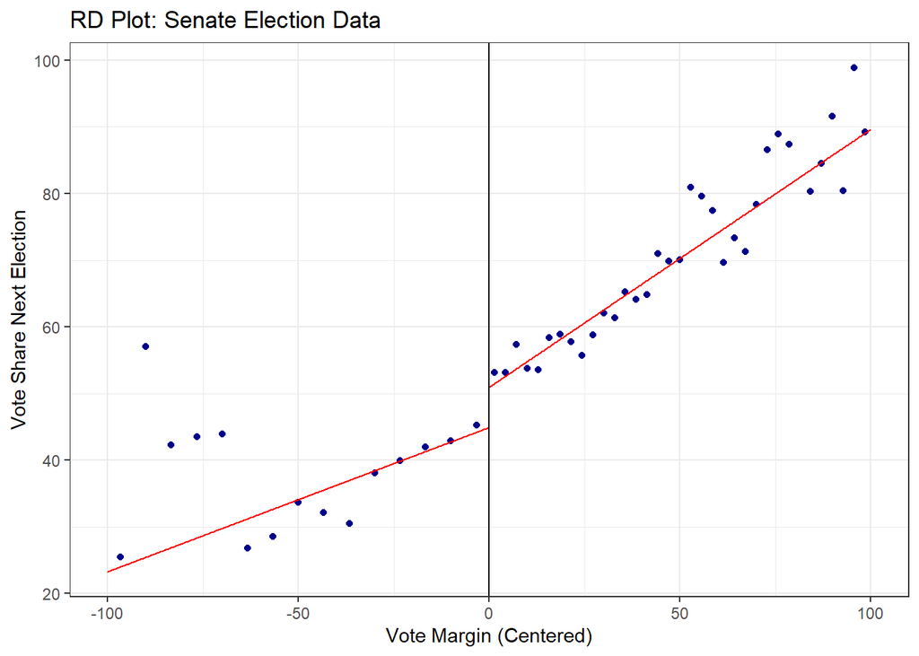

## Interpreting the Plot:

Using `rdplot()` allows for a simple way to capture the slope on each side of the cutoff, whereas our earlier naive (biased) `lm()` model assumed parallel lines and we had to then include an interaction term for dual slopes.